# Sesion_7

Jairo Udaneta y Adrian Villegas

2026-05-21

# Elastic Net

## Si elijo una elastic net para penalizar mi modelo ¿que alpha y s elijo?

```r
dim(student_digital_life)
```

```
## [1] 15000    18
```

El uso de la penalización con Elastic Net es recomendado cuando tenemos un dataset con un mayor numeros de variables que de muentras. En nuestro caso nosotros tenemos una base de datos con 15000 muestras y 18 variables, a continuación observaremos que sucede si aplicamos este metodo de penalización.

Continuaremos usando de base el modelo mejorado obtenido en la sesión 6.

```r
modelo_multivariable_smart_mejorado <- lm(smartphone_usage_hours ~ study_hours_per_day + social_media_hours +
              gaming_hours + sleep_hours + exercise_hours +
              class_attendance_percent + assignment_completion_percent +
              mental_health_status + parent_education_level +
              motivation_level + final_exam_score,
              data = student_digital_life)

summary(modelo_multivariable_smart_mejorado )
```

```
##
## Call:
## lm(formula = smartphone_usage_hours ~ study_hours_per_day + social_media_hours +
##     gaming_hours + sleep_hours + exercise_hours + class_attendance_percent +
##     assignment_completion_percent + mental_health_status + parent_education_level +
##     motivation_level + final_exam_score, data = student_digital_life)
##
## Residuals:
##     Min      1Q  Median      3Q     Max
## -6.6149 -1.6252 -0.0128  1.5934  8.3212
##
## Coefficients:
##                                   Estimate Std. Error t value Pr(>|t|)
## (Intercept)                       4.968823   0.246919  20.123  < 2e-16 ***
## study_hours_per_day               0.259470   0.013771  18.842  < 2e-16 ***
## social_media_hours                0.028249   0.011010   2.566 0.010301 *
## gaming_hours                     -0.048245   0.013392  -3.602 0.000316 ***
## sleep_hours                       0.050279   0.013439   3.741 0.000184 ***
## exercise_hours                    0.070716   0.023629   2.993 0.002770 **
## class_attendance_percent          0.014340   0.002101   6.826 9.08e-12 ***
## assignment_completion_percent     0.010119   0.001459   6.938 4.15e-12 ***
## mental_health_statusGood          0.074662   0.044320   1.685 0.092083 .
## mental_health_statusPoor         -0.313703   0.053697  -5.842 5.26e-09 ***
## parent_education_levelHighSchool -0.032712   0.045038  -0.726 0.467650
## parent_education_levelMasters     0.110481   0.054557   2.025 0.042881 *
## parent_education_levelPhD         0.126354   0.097302   1.299 0.194110
## motivation_level                  0.068346   0.010261   6.661 2.82e-11 ***
## final_exam_score                 -0.043191   0.001613 -26.776  < 2e-16 ***
## ---
## Signif. codes:  0 '***' 0.001 '**' 0.01 '*' 0.05 '.' 0.1 ' ' 1
##
## Residual standard error: 2.381 on 14985 degrees of freedom
## Multiple R-squared:  0.04688,    Adjusted R-squared:  0.04599
## F-statistic: 52.64 on 14 and 14985 DF,  p-value: < 2.2e-16
```

**Elección de alpha (S)**

Utilizamos la matriz de correlación para poder elegir el valor de alpha.

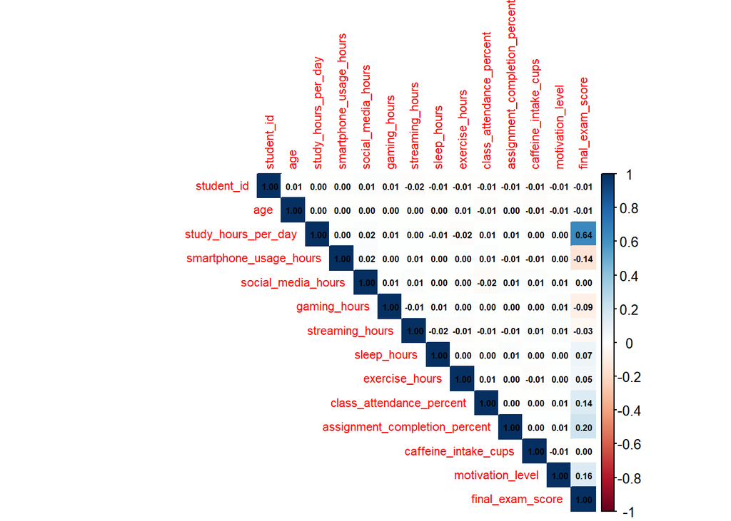

```r
num_vars <- student_digital_life[, sapply(student_digital_life, is.numeric)]
cor_matrix <- cor(num_vars)
corrplot(cor_matrix, method = "color", type = "upper",
         tl.cex = 0.7, addCoef.col = "black", number.cex = 0.5)
```

Como la mayoria de correlaciones son cercanas a cero, elegiremos un alpha de 1, es decir un modelo de Lasso(L1)

Preparamos las matrices para usar glmnet, y ejecutamos una validación cruzada para elergir S.

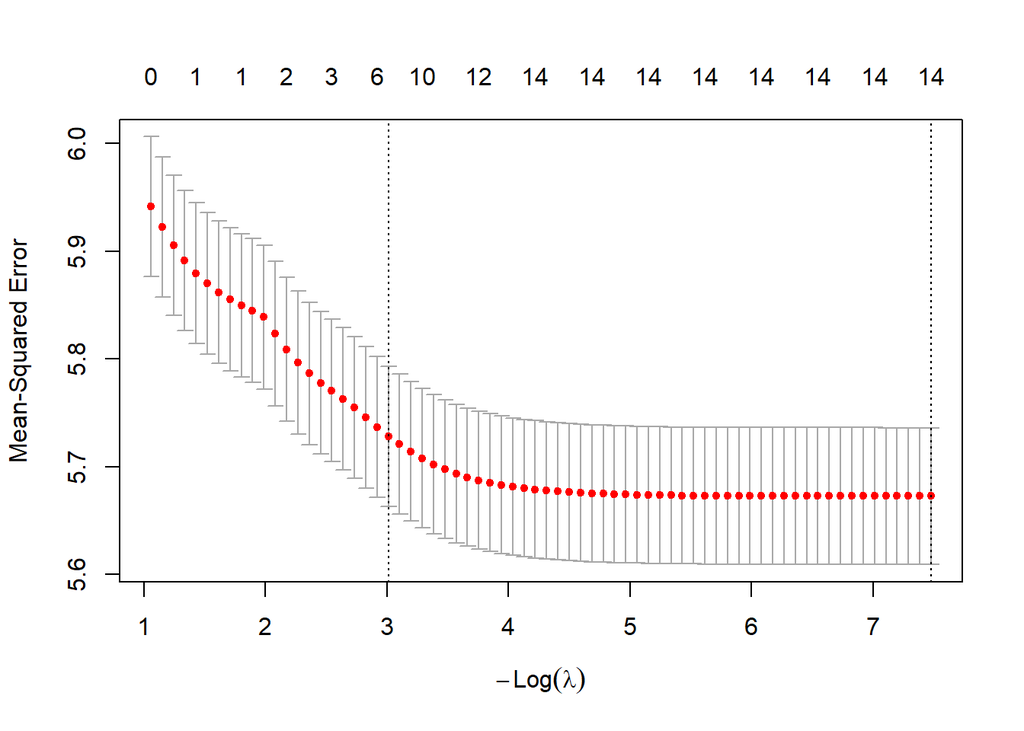

```r
X <- model.matrix(modelo_multivariable_smart_mejorado, data = student_digital_life)[, -1]
Y <- student_digital_life$smartphone_usage_hours

set.seed(123)
cv_enet <- cv.glmnet(X, Y, alpha = 1, nfolds = 10)
plot(cv_enet)
```

Separamos los datos para la evaluación de modelo lineal y creamos las matrices que usará glmnet para realizar el Lasso.

```r
set.seed(42)
idx <- sample(1:nrow(student_digital_life), 0.8 * nrow(student_digital_life))


df_train <- student_digital_life[idx, ]
df_test  <- student_digital_life[-idx, ]


X <- model.matrix(smartphone_usage_hours ~ study_hours_per_day + social_media_hours +
                  gaming_hours + sleep_hours + exercise_hours +
                  class_attendance_percent + assignment_completion_percent +
                  mental_health_status + parent_education_level +
                  motivation_level + final_exam_score,
                  data = student_digital_life)[, -1]

X_train <- X[idx, ]
X_test  <- X[-idx, ]
Y_train <- student_digital_life$smartphone_usage_hours[idx]
Y_test  <- student_digital_life$smartphone_usage_hours[-idx]
```

Entramos ámbos modelos.

```r
modelo_lm_limpio <- lm(smartphone_usage_hours ~ study_hours_per_day + social_media_hours +
                       gaming_hours + sleep_hours + exercise_hours +
                       class_attendance_percent + assignment_completion_percent +
                       mental_health_status + parent_education_level +
                       motivation_level + final_exam_score,
                       data = df_train) # ¡AQUÍ ESTÁ LA CLAVE! Usar data = df_train


cv_lasso <- cv.glmnet(X_train, Y_train, alpha = 1, nfolds = 10)
```

Procedemos a evaluarlos

```r
#Predicciones
pred_lm <- predict(modelo_lm_limpio, newdata = df_test)
pred_lasso <- predict(cv_lasso, newx = X_test, s = "lambda.1se") # Usamos el modelo más simple

#RMSE
rmse_lm <- sqrt(mean((Y_test - pred_lm)^2))
rmse_lasso <- sqrt(mean((Y_test - pred_lasso)^2))

cat("RMSE OLS Limpio:", round(rmse_lm, 3), "\nRMSE Lasso:", round(rmse_lasso, 3))
```

```
## RMSE OLS Limpio: 2.374
## RMSE Lasso: 2.389
```

# GAM

El primer paso para crear un modelo adictivo generalizado es visualizar que variables son continuas (las cuales suavizaremos con s() ) y las categorias (las cuales mantendremos como terminos lineales)

```r
# Verificar la estructura del dataset
str(student_digital_life)
```

```
## spc_tbl_ [15,000 × 18] (S3: spec_tbl_df/tbl_df/tbl/data.frame)
##  $ student_id                   : num [1:15000] 1 2 3 4 5 6 7 8 9 10 ...
##  $ age                          : num [1:15000] 21 23 20 20 24 24 24 25 25 24 ...
##  $ gender                       : Factor w/ 2 levels "Female","Male": 1 1 1 1 2 1 1 2 2 2 ...
##  $ study_hours_per_day          : num [1:15000] 3.01 5.84 7.8 0 7.23 1.51 4.38 4.86 3.8 4.28 ...
##  $ smartphone_usage_hours       : num [1:15000] 0.26 8.02 10.13 1.15 1.39 ...
##  $ social_media_hours           : num [1:15000] 1.77 3.3 0 1.32 2.21 2.61 4.43 4.76 6.82 2.37 ...
##  $ gaming_hours                 : num [1:15000] 0.26 0.96 2.23 4.19 4.67 4.38 0.59 0 1.98 2.99 ...
##  $ streaming_hours              : num [1:15000] 1.71 0 2.54 0.27 2.75 2.17 1.65 3.01 0 4.17 ...
##  $ sleep_hours                  : num [1:15000] 5.32 5.99 6.36 7.86 7.88 4.52 7.37 5.21 7.41 5.74 ...
##  $ exercise_hours               : num [1:15000] 0.7 1.99 1.82 0.18 0.28 1 0.6 0.71 1.14 1.27 ...
##  $ class_attendance_percent     : num [1:15000] 64.9 85.4 76.2 84.4 81.1 ...
##  $ assignment_completion_percent: num [1:15000] 74.1 80.7 79.7 79.1 65.4 ...
##  $ caffeine_intake_cups         : num [1:15000] 2 3 2 0 4 2 1 1 0 3 ...
##  $ mental_health_status         : Factor w/ 3 levels "Average","Good",..: 2 1 2 1 2 2 2 1 2 1 ...
##  $ parent_education_level       : Factor w/ 4 levels "Bachelors","HighSchool",..: 3 3 2 2 2 2 2 3 2 2 ...
##  $ internet_quality             : Factor w/ 3 levels "Average","Good",..: 1 3 3 1 1 1 1 1 1 3 ...
##  $ motivation_level             : num [1:15000] 6.32 2.52 3.98 4.77 8.77 5.81 3.79 3.76 3.43 7.18 ...
##  $ final_exam_score             : num [1:15000] 82.7 85.7 88.1 54.8 84.3 ...
##  - attr(*, "spec")=
##   .. cols(
##   ..   student_id = col_double(),
##   ..   age = col_double(),
##   ..   gender = col_character(),
##   ..   study_hours_per_day = col_double(),
##   ..   smartphone_usage_hours = col_double(),
##   ..   social_media_hours = col_double(),
##   ..   gaming_hours = col_double(),
##   ..   streaming_hours = col_double(),
##   ..   sleep_hours = col_double(),
##   ..   exercise_hours = col_double(),
##   ..   class_attendance_percent = col_double(),
##   ..   assignment_completion_percent = col_double(),
##   ..   caffeine_intake_cups = col_double(),
##   ..   mental_health_status = col_character(),
##   ..   parent_education_level = col_character(),
##   ..   internet_quality = col_character(),
##   ..   motivation_level = col_double(),
##   ..   final_exam_score = col_double()
##   .. )
##  - attr(*, "problems")=<externalptr>
```

Con esta información creamos el GAM

```r
modelo_gam <- gam(
  smartphone_usage_hours ~
    s(study_hours_per_day) +
    s(social_media_hours) +
    s(gaming_hours) +
    s(sleep_hours) +
    s(exercise_hours) +
    s(class_attendance_percent) +
    s(assignment_completion_percent) +
    mental_health_status +
    parent_education_level +
    s(motivation_level) +
    s(final_exam_score),
  data = student_digital_life,
  method = "REML"
)

summary(modelo_gam)
```

```
##
## Family: gaussian
## Link function: identity
##
## Formula:
## smartphone_usage_hours ~ s(study_hours_per_day) + s(social_media_hours) +
##     s(gaming_hours) + s(sleep_hours) + s(exercise_hours) + s(class_attendance_percent) +
##     s(assignment_completion_percent) + mental_health_status +
##     parent_education_level + s(motivation_level) + s(final_exam_score)
##
## Parametric coefficients:
##                                  Estimate Std. Error t value Pr(>|t|)
## (Intercept)                       5.54340    0.03885 142.681  < 2e-16 ***
## mental_health_statusGood          0.09763    0.04422   2.208   0.0273 *
## mental_health_statusPoor         -0.39242    0.05379  -7.296 3.12e-13 ***
## parent_education_levelHighSchool -0.05886    0.04487  -1.312   0.1896
## parent_education_levelMasters     0.11489    0.05427   2.117   0.0343 *
## parent_education_levelPhD         0.14013    0.09681   1.447   0.1478
## ---
## Signif. codes:  0 '***' 0.001 '**' 0.01 '*' 0.05 '.' 0.1 ' ' 1
##
## Approximate significance of smooth terms:
##                                    edf Ref.df       F  p-value
## s(study_hours_per_day)           4.954  6.048  80.619  < 2e-16 ***
## s(social_media_hours)            1.013  1.026   6.011 0.013326 *
## s(gaming_hours)                  2.153  2.722   8.113 7.49e-05 ***
## s(sleep_hours)                   7.415  8.368  10.901  < 2e-16 ***
## s(exercise_hours)                1.008  1.016  12.642 0.000359 ***
## s(class_attendance_percent)      1.005  1.009  62.902  < 2e-16 ***
## s(assignment_completion_percent) 1.391  1.689  43.648  < 2e-16 ***
## s(motivation_level)              1.727  2.175  27.715  < 2e-16 ***
## s(final_exam_score)              4.214  5.204 170.308  < 2e-16 ***
## ---
## Signif. codes:  0 '***' 0.001 '**' 0.01 '*' 0.05 '.' 0.1 ' ' 1
##
## R-sq.(adj) =  0.0573   Deviance explained = 5.91%
## -REML =  34259  Scale est. = 5.6011    n = 15000
```

Observamos en el análisis del modelo obtenido que en los terminos lineales parent_education_level no aporta mucha información a la predicción debido a que solamente uno de sus valores categoricos tiene un p-value menor que 0,05. Por otro lado, mental_health_status si que aporta más infomación, ya que es estadisticamente significante en sus dos valores categoricos.

En cuanto a las funciones suavizadas observamos que todas son estadisticamen significantes, y que la mayoría tiene un edf mayor que 1, lo que significa que no sigue una relación lineal y que el suavizado a cumplido su proposito. Sin embargo, funciones suavizadas como s(social_media_hours), s(exercise_hours) y s(class_attendance_percent) las cuales tienen valores muy cercanas a 1, indicandonos que el suavizado no aporto nada, ya que siguen practicamente una relación lineal

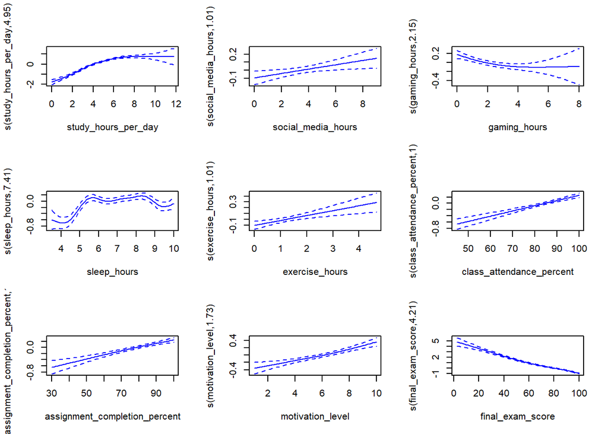

```r
par(mfrow = c(3, 3))
plot(modelo_gam, shade = TRUE, col = "blue", shade.col = "lightblue",
     seWithMean = TRUE, scale = 0)
```

En estas graficas observamos de manera visual que las funciones de suavizado con un edf muy cercano a uno siguen practicamente una regresión lineal.

# GLMMs

Para saber si podemos crear un GLMMs con nuestro dataset, tenemos que ver si las observaciones son independientes o dependientes.

```r
n_distinct(student_digital_life$mental_health_status)
```

```
## [1] 3
```

```r
n_distinct(student_digital_life$parent_education_level)
```

```
## [1] 4
```

```r
n_distinct(student_digital_life$gender)
```

```
## [1] 2
```

```r
head(student_digital_life, 10)
```

```
## # A tibble: 10 × 18
##    student_id   age gender study_hours_per_day smartphone_usage_hours
##         <dbl> <dbl> <fct>                <dbl>                  <dbl>
##  1          1    21 Female                3.01                   0.26
##  2          2    23 Female                5.84                   8.02
##  3          3    20 Female                7.8                   10.1
##  4          4    20 Female                0                      1.15
##  5          5    24 Male                  7.23                   1.39
##  6          6    24 Female                1.51                   7.45
##  7          7    24 Female                4.38                   2.57
##  8          8    25 Male                  4.86                   7.22
##  9          9    25 Male                  3.8                    6.8
## 10         10    24 Male                  4.28                   5.3
## # ℹ 13 more variables: social_media_hours <dbl>, gaming_hours <dbl>,
## #   streaming_hours <dbl>, sleep_hours <dbl>, exercise_hours <dbl>,
## #   class_attendance_percent <dbl>, assignment_completion_percent <dbl>,
## #   caffeine_intake_cups <dbl>, mental_health_status <fct>,
## #   parent_education_level <fct>, internet_quality <fct>,
## #   motivation_level <dbl>, final_exam_score <dbl>
```

Observamos en el análisis obtenido del dataset que no hay observaciones de estudiantes repetidos ni variables de agrupación. Además, las variables categoricas que tenemos tienen muy pocos niveles. Por lo que concluimos que no seria eficiente realizar un GLMM con nuestro datase.